# project_2_titanic

## Written in the beginning

Up to now, I have learned about the basic steps on data analysis process. Also, I studied some typical functions on Numpy, Pandas and Matplotlib. Next, I would take the knowledge of mine and try to finish the first data analysis project.

Here, I'm interested in Titanic dataset, will study if any finding on that.

## QUESTION

I would like to investigate what factors made people more likely to survive from below

- How many persons survived the Titanic?
- Which P class had the most survivors?
- Which port embarked had the most survivors?
- Which gender survived with a higher count, Male or Female?
- Which age group survived ?

## Load data

```python
import numpy as np
import pandas as pd
import matplotlib.pyplot as plt
%pylab inline
import seaborn as sns

#create dataframe for Titanic data
titanic_df = pd.read_csv('titanic_data.csv')
```

## Know the data

```python
titanic_df.shape
```

```
(891, 12)
```

There are total 891 passenger's records with 12 columns in the raw table

```python
titanic_df.info()
```

```
<class 'pandas.core.frame.DataFrame'>
RangeIndex: 891 entries, 0 to 890
Data columns (total 12 columns):
PassengerId    891 non-null int64
Survived       891 non-null int64
Pclass         891 non-null int64
Name           891 non-null object
Sex            891 non-null object
Age            714 non-null float64
SibSp          891 non-null int64
Parch          891 non-null int64
Ticket         891 non-null object
Fare           891 non-null float64
Cabin          204 non-null object
Embarked       889 non-null object
dtypes: float64(2), int64(5), object(5)
memory usage: 83.6+ KB
```

From the output, I can find only 714 passengers have age information, however, age column would be one of the factors to be investigated, I need to remove the passenger who didn't have age record later.

```python
titanic_df.describe()
```

|  | PassengerId | Survived | Pclass | Age | SibSp | Parch | Fare |
| --- | --- | --- | --- | --- | --- | --- | --- |
| count | 891.000000 | 891.000000 | 891.000000 | 714.000000 | 891.000000 | 891.000000 | 891.000000 |
| mean | 446.000000 | 0.383838 | 2.308642 | 29.699118 | 0.523008 | 0.381594 | 32.204208 |
| std | 257.353842 | 0.486592 | 0.836071 | 14.526497 | 1.102743 | 0.806057 | 49.693429 |
| min | 1.000000 | 0.000000 | 1.000000 | 0.420000 | 0.000000 | 0.000000 | 0.000000 |
| 25% | 223.500000 | 0.000000 | 2.000000 | 20.125000 | 0.000000 | 0.000000 | 7.910400 |
| 50% | 446.000000 | 0.000000 | 3.000000 | 28.000000 | 0.000000 | 0.000000 | 14.454200 |
| 75% | 668.500000 | 1.000000 | 3.000000 | 38.000000 | 1.000000 | 0.000000 | 31.000000 |
| max | 891.000000 | 1.000000 | 3.000000 | 80.000000 | 8.000000 | 6.000000 | 512.329200 |

```python
# total survivals
titanic_df[titanic_df['Survived']==1]['Survived'].count()
```

```
342
```

## Data cleaning

Being observed from above section, there were only 714 out of 891 passengers have age information, since I need to have analysis for age and survivors, I have to handling the missing values for age. we assume that missing values are distributed similarly to the values that are present, here, I will fill the missing age with mean.

Next, as the age are discrete with too many values, to compare the age and survivor and clearly visualize the ages with plot for my further analysis, I am going to group the age by every ten years old for passengers.

```python
# 1. Replace the missing age with mean
passenger_mean_age=titanic_df['Age'].mean()
titanic_df['Age'].fillna(passenger_mean_age,inplace=True)

# 2. Group passenger's age as following

# < 10    : less_than_ten
# 10 - 20 : ten_to_twenty
# 20 - 30 : twenty_to_thirty
# 30 - 40 : thirty_to_fourty
# 40 - 50 : fourty_to_fifty
# 50 - 60 : fifty_to_sixty
# 60 - 70 : sixty_to_seventy
# > 70    : greater_than_seventy

def add_passenger_Age_stage(age):
    if age < 10:
        return 'less_than_ten'
    elif age < 20:
        return 'ten_to_twenty'
    elif age < 30:
        return 'twenty_to_thirty'
    elif age < 40:
        return 'thirty_to_fourty'
    elif age < 50:
        return 'fourty_to_fifty'
    elif age < 60:
        return 'fifty_to_sixty'
    elif age < 70:
        return 'sixty_to_seventy'
    else:
        return 'greater_than_seventy'

# Add new columns to existing dataframe
def patch_df(titanic_df):
    titanic_df['Age_stage'] = titanic_df['Age'].apply(add_passenger_Age_stage)

patch_df(titanic_df)
titanic_df.head(10)
```

|  | PassengerId | Survived | Pclass | Name | Sex | Age | SibSp | Parch | Ticket | Fare | Cabin | Embarked | Age_stage |
| --- | --- | --- | --- | --- | --- | --- | --- | --- | --- | --- | --- | --- | --- |
| 0 | 1 | 0 | 3 | Braund, Mr. Owen Harris | male | 22.000000 | 1 | 0 | A/5 21171 | 7.2500 | NaN | S | twenty_to_thirty |
| 1 | 2 | 1 | 1 | Cumings, Mrs. John Bradley (Florence Briggs Th... | female | 38.000000 | 1 | 0 | PC 17599 | 71.2833 | C85 | C | thirty_to_fourty |
| 2 | 3 | 1 | 3 | Heikkinen, Miss. Laina | female | 26.000000 | 0 | 0 | STON/O2. 3101282 | 7.9250 | NaN | S | twenty_to_thirty |
| 3 | 4 | 1 | 1 | Futrelle, Mrs. Jacques Heath (Lily May Peel) | female | 35.000000 | 1 | 0 | 113803 | 53.1000 | C123 | S | thirty_to_fourty |
| 4 | 5 | 0 | 3 | Allen, Mr. William Henry | male | 35.000000 | 0 | 0 | 373450 | 8.0500 | NaN | S | thirty_to_fourty |
| 5 | 6 | 0 | 3 | Moran, Mr. James | male | 29.699118 | 0 | 0 | 330877 | 8.4583 | NaN | Q | twenty_to_thirty |
| 6 | 7 | 0 | 1 | McCarthy, Mr. Timothy J | male | 54.000000 | 0 | 0 | 17463 | 51.8625 | E46 | S | fifty_to_sixty |
| 7 | 8 | 0 | 3 | Palsson, Master. Gosta Leonard | male | 2.000000 | 3 | 1 | 349909 | 21.0750 | NaN | S | less_than_ten |
| 8 | 9 | 1 | 3 | Johnson, Mrs. Oscar W (Elisabeth Vilhelmina Berg) | female | 27.000000 | 0 | 2 | 347742 | 11.1333 | NaN | S | twenty_to_thirty |
| 9 | 10 | 1 | 2 | Nasser, Mrs. Nicholas (Adele Achem) | female | 14.000000 | 1 | 0 | 237736 | 30.0708 | NaN | C | ten_to_twenty |

## Data exploration

```python
# new dataframe to store passenger survived
def survived_passenger_df(titanic_df):
    return titanic_df[titanic_df.Survived==1]

# Calculate the number of group data
def count_group_data(titanic_df,group_key):
    return titanic_df.groupby(group_key)['PassengerId'].count()

# Calculate the rate of survived passenger
def rate_of_survived_passenger(group_data,group_key):
    # Calculate number of all passenger in the group
    all_passenger_of_each_group = count_group_data(titanic_df,group_key)

    # Calculate number of all passenger survived in the group
    survived_passenger_of_each_group = count_group_data(survived_passenger_df(group_data),group_key)

    # Return the rate of survived passenger
    return survived_passenger_of_each_group / all_passenger_of_each_group

# Print the histogram chart
def print_bar(group_data,title,xlab,ylab):
    sns.set_style("whitegrid")
    group_data.plot.bar(title=title,
                        figsize=(5,5),
                        color='b',
                        alpha=0.6
                       )
    xlabel(xlab,fontsize=12 )
    ylabel(ylab,fontsize=12 )


# Print the pie chart
def print_pie(group_data,titel,label):
    figure
    figure(figsize=(6, 6))
    plt.pie(group_data,
            autopct='%3.1f%%',
            shadow=True,
            #explode=[0.1,0,0],
            startangle = 90
            #labels=label
           )
    plt.title(titel)
    plt.legend(label)
```

### Passenger and ticket class of passenger hold

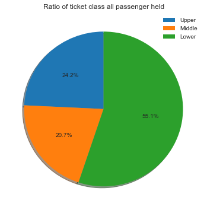

```python
# The P class ratio of all passengers
titel = 'Ratio of ticket class all passenger held'
labels = ['Upper','Middle','Lower']
print_pie(count_group_data(titanic_df,'Pclass'),
          titel,
          labels
         )
```

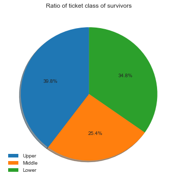

```python
# The Pclass ratio of all passengers survived

titel = 'Ratio of ticket class of survivors'
print_pie(count_group_data(survived_passenger_df(titanic_df),'Pclass'),
          titel,
          labels
         )
```

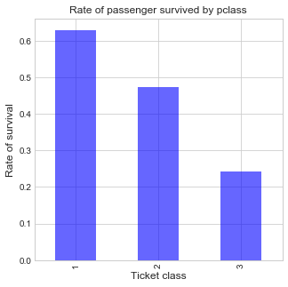

```python
# The survival rate of different Pclass

rate_of_survived_passenger_sex = rate_of_survived_passenger(titanic_df,'Pclass')
print_bar(rate_of_survived_passenger_sex,
          'Rate of passenger survived by pclass',
          'Ticket class',
          'Rate of survival')
```

According to the statistical chart, we observed there were over half of Titanic passenger held the 3rd ticket, the percentage is 55.1% from all passenger. However, the largest percentage of survivors hold a 1st ticket,it's 39.8%. and see from the rate of passenger survived, over 60% of them were survived who held 1st ticket, and only about 24% passenger were survived who held 3rd ticket.

### Passenger and port of embarkation

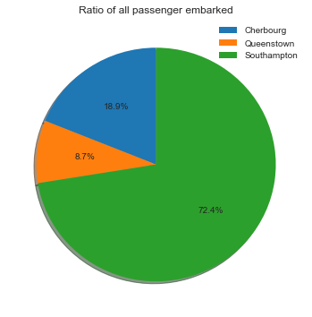

```python
# The port of Embarkation ratio of all passengers

titel = 'Ratio of all passenger embarked'
labels = ['Cherbourg', 'Queenstown', 'Southampton']
print_pie(count_group_data(titanic_df,'Embarked'),
          titel,
          labels
         )
```

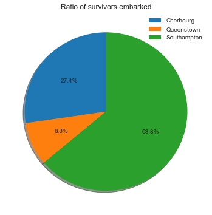

```python
# The port of Embarkation ratio of all passengers survived
titel = 'Ratio of survivors embarked'
print_pie(count_group_data(survived_passenger_df(titanic_df),'Embarked'),
          titel,
          labels
         )
```

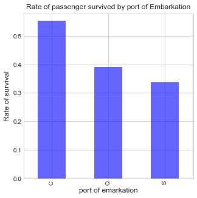

```python
# The survival rate of different ports of Embarkation
rate_of_survived_passenger_sex = rate_of_survived_passenger(titanic_df,'Embarked')
print_bar(rate_of_survived_passenger_sex,
          'Rate of passenger survived by port of Embarkation',
          'port of emarkation',
          'Rate of survival'
         )
```

We observed that most of passenger with percentage 72.4% were embarked from Southampton,and 63.8% percent of those who survived came on board the port. however, the passenger embarked from Cherbourg had the larget rate in survived people.

### Passenger and sex

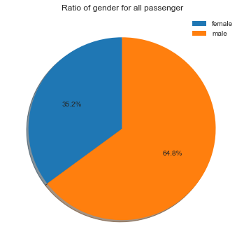

```python
# The sex ratio of all passengers

#print_pie(count_group_data(titanic_df,'Sex'),title='All passenger by sex')
titel = 'Ratio of gender for all passenger'
labels = ['female', 'male']
print_pie(count_group_data(titanic_df,'Sex'),
          titel,
          labels
         )
```

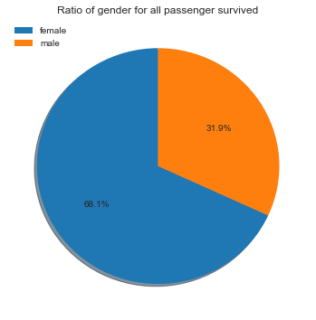

```python
# The sex ratio of all passengers survived

titel = 'Ratio of gender for all passenger survived'
print_pie(count_group_data(survived_passenger_df(titanic_df),'Sex'),
          titel,
          labels
         )
```

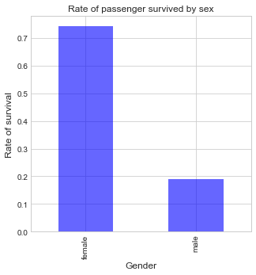

```python
# The survival rate of different sexes
rate_of_survived_passenger_sex = rate_of_survived_passenger(titanic_df,'Sex')
print_bar(rate_of_survived_passenger_sex,
          'Rate of passenger survived by sex',
          'Gender',
          'Rate of survival'
         )
```

64.8% of passenger were men for overall on board, however, 68.1% of passenger surived were women, the rate of women survived is over 70%, that's far more than the proportion of men.

### Passenger and age

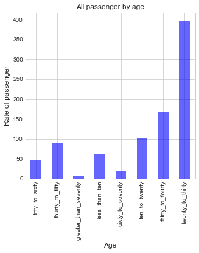

```python
# The ratio of age group for all passengers

print_bar(count_group_data(titanic_df,'Age_stage'),
          'All passenger by age',
          'Age',
          'Rate of passenger'
         )
```

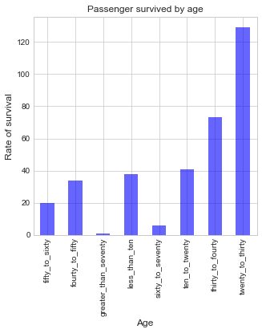

```python
# The ratio age group of all passengers survived

print_bar(count_group_data(survived_passenger_df(titanic_df),'Age_stage'),
          'Passenger survived by age',
          'Age',
          'Rate of survival'
         )
```

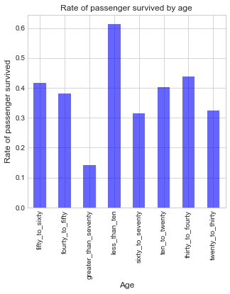

```python
# The survival rate of different age group
print_bar(rate_of_survived_passenger(titanic_df,'Age_stage') ,
          'Rate of passenger survived by age',
          'Age',
          'Rate of passenger survived'
         )
```

From the age analysis, we observed that the largest number of passengers falls in from 20 - 30 years old, also the largest number of passengers survived falls in from 20 - 30 years old. However, the largest rate of passengers survived is kids less than 10 years old.

### Pearson correlation r

```python
# This function is to calculate Pearson's r
# r = average of (x in std unit) * (y in std unit)
def correlation(x,y):
    std_x = (x - x.mean()) / x.std(ddof=0)
    std_y = (y - y.mean()) / y.std(ddof=0)

    return (std_x * std_y).mean()

correlation(titanic_df['Pclass'],titanic_df['Survived'])
```

```
-0.33848103596101325
```

From above pearson correlation r for Pclass' and 'Survived', it's negative correlation, that means the upper ticket class, the higher the rate of survival, however, the r=-0.34 a little bit small from (-1).

## Conclusions

### Limitations of analysis

There is no statistical analysis to support these results, so it is not known whether the results here are caused by real differences or noise.

In addition, the age field has some missing values, and we are replacing the missing value with the average age of all passengers. Such a practice would make most passenger fall in the age group and affect the results of the comparison.

### Other factors that may affect survival rates

Actually,there are other factors that may affect survival rates, such as passenger occupation, survival ability, etc., but the data set is not given.